# IA para Científicos Sociales

Sesión 2.1: Métodos de clasificación

Danilo Freire

danilofreire@gmail.com

Department of Data and Decision Sciences  
Emory University

# Día 2: Aprendizaje supervisado

## Repaso del Día 1

- La IA busca crear sistemas capaces de realizar tareas que requieren inteligencia humana
- Tres tipos de aprendizaje: supervisado, no supervisado y por refuerzo
- El flujo de trabajo de ML: recoger, preprocesar, dividir, entrenar, evaluar
- Sobreajuste (*overfitting*): memorizar en lugar de aprender
- La exactitud (*accuracy*) no es suficiente: necesitamos precisión, recall y otras métricas
- Ayer hicimos nuestros primeros modelos con [tidymodels](https://www.tidymodels.org/), una interfaz unificada para ML en R

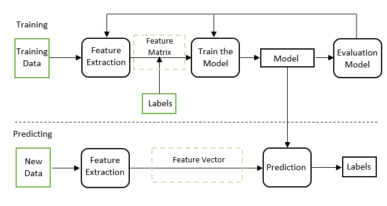

## Agenda de la sesión

- Regresión logística (profundización)
- Árboles de decisión
- Random Forests
- Interpretación de importancia de variables
- Ajuste de hiperparámetros (tuning)
- Gradient Boosting (XGBoost)
- Comparación sistemática de modelos
- Aplicaciones

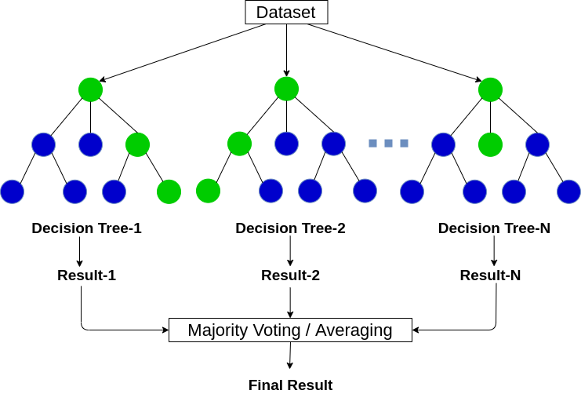

# Regresión logística

## Regresión logística: profundización

- Regresión logística: predice la probabilidad de pertenecer a una clase
- Usa la función sigmoide para transformar una combinación lineal en una probabilidad entre 0 y 1:

$$P(y = 1 | x) = \frac{1}{1 + e^{-(w_0 + w_1 x_1 + \ldots + w_n x_n)}}$$

- Los coeficientes ($w$) indican la dirección (positivo o negativo) y la fuerza del efecto
- Interpretable: “por cada año adicional de educación, las chances de votar aumentan un X%”

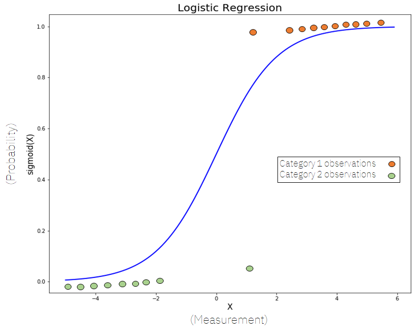

La función sigmoide transforma valores lineales en probabilidades

Fuente: [Wikipedia](https://en.wikipedia.org/wiki/Logistic_function)

## ¿Cuándo usar regresión logística?

**Ventajas**

- Simple e interpretable: los coeficientes tienen significado claro
- Rápida de entrenar, funciona bien con pocos datos
- Produce probabilidades, no solo clases
- Buena línea base (baseline) antes de probar modelos más complejos

**Limitaciones**

- Asume relaciones lineales entre predictores y log-odds
- No captura interacciones complejas ni patrones no lineales automáticamente

**Usos comunes en ciencias sociales**

- Comportamiento electoral: ¿qué predice si alguien vota por un candidato?
- Conflicto: ¿qué factores predicen un conflicto armado?
- Pobreza: ¿qué variables predicen si un hogar está por debajo de la línea de pobreza?
- Migración: ¿qué factores predicen la intención de emigrar?

La interpretabilidad es clave para informar políticas públicas, aunque a veces sacrifiquemos capacidad predictiva

## Ejemplo: Apoyo a la democracia en Uruguay

**Pregunta de investigación:** ¿qué factores predicen si un uruguayo apoya la democracia? Datos del Latinobarómetro para Uruguay (simulados)

**Variables:** edad, educación, ingreso, confianza en instituciones, percepción económica, zona, género

**Variable de respuesta:** `apoya_democracia` (sí/no)

La regresión logística nos dice qué factores aumentan o disminuyen la probabilidad de apoyo, y en qué magnitud

```r
R> ajuste_log <- logistic_reg() |>
+   set_engine("glm") |>
+   set_mode("classification") |>
+   fit(apoya_democracia ~ ., data = datos_train)
```

**Resultados (datos simulados, n = 1125):**

**Código**

```r
R> broom::tidy(ajuste_log) |>
+   dplyr::mutate(
+     odds_ratio = exp(estimate),
+     sig = dplyr::case_when(
+       p.value < 0.001 ~ "***",
+       p.value < 0.01  ~ "**",
+       p.value < 0.05  ~ "*",
+       TRUE            ~ ""
+     ),
+     term = dplyr::recode(term,
+       `(Intercept)` = "Intercept",
+       `zonaurbano`  = "zona_urbano"
+     )
+   ) |>
+   dplyr::select(Variable = term,
+                 Coef = estimate,
+                 `Odds Ratio` = odds_ratio,
+                 ` ` = sig) |>
+   knitr::kable(digits = 2, align = c("l", "r", "r", "l"))
```

| Variable | Coef | Odds Ratio |  |
| --- | --- | --- | --- |
| Intercept | -4.40 | 0.01 | *** |
| edad | 0.01 | 1.01 | ** |
| educacion_anos | 0.09 | 1.09 | *** |
| ingreso_log | 0.21 | 1.23 | ** |
| confianza_gobierno | 0.23 | 1.25 | *** |
| percepcion_economia | 0.31 | 1.36 | *** |
| zona_urbano | -0.11 | 0.90 |  |
| generomasculino | -0.08 | 0.92 |  |

*** p < 0.001, ** p < 0.01, * p < 0.05

Pregunta: ¿qué significa un OR de 1.25 para confianza en el gobierno?

## Odds ratios: interpretación práctica

- Los coeficientes de regresión logística están en escala log-odds
- Para interpretarlos, usamos el odds ratio = $e^{\beta}$

**Interpretación del odds ratio:**

- OR = 1: sin efecto
- OR > 1: aumenta las chances (odds)
- OR < 1: disminuye las chances

**Ejemplo:** OR = 1.25 para confianza en el gobierno

- Por cada punto adicional de confianza (escala 1-10), las chances de apoyar la democracia se multiplican por 1.25
- Es decir, aumentan un 25%

**Cálculo en R:**

```r
R> tidy(ajuste_log) |>
+   mutate(
+     OR     = exp(estimate),
+     IC_inf = exp(estimate - 1.96 * std.error),
+     IC_sup = exp(estimate + 1.96 * std.error)
+   ) |>
+   select(term, OR, IC_inf, IC_sup) |>
+   knitr::kable(digits = 2)
```

| term | OR | IC_inf | IC_sup |
| --- | --- | --- | --- |
| (Intercept) | 0.01 | 0.00 | 0.05 |
| edad | 1.01 | 1.00 | 1.02 |
| educacion_anos | 1.09 | 1.05 | 1.13 |
| ingreso_log | 1.23 | 1.07 | 1.42 |
| confianza_gobierno | 1.25 | 1.19 | 1.32 |
| percepcion_economia | 1.36 | 1.23 | 1.51 |
| zonaurbano | 0.90 | 0.61 | 1.31 |
| generomasculino | 0.92 | 0.70 | 1.22 |

Siempre reportar intervalos de confianza para los odds ratios

# Árboles de decisión

## ¿Qué es un árbol de decisión?

- Un árbol de decisión aprende una jerarquía de preguntas de sí/no
- Cada nodo divide los datos según una variable
- Cada hoja contiene una predicción
- Ejemplo: “Si la educación > 12 años Y la edad > 30, entonces predecir: votó”
- Puede capturar relaciones no lineales
- Muy fácil de interpretar: se visualiza como un diagrama de flujo que cualquiera entiende, incluso sin formación técnica

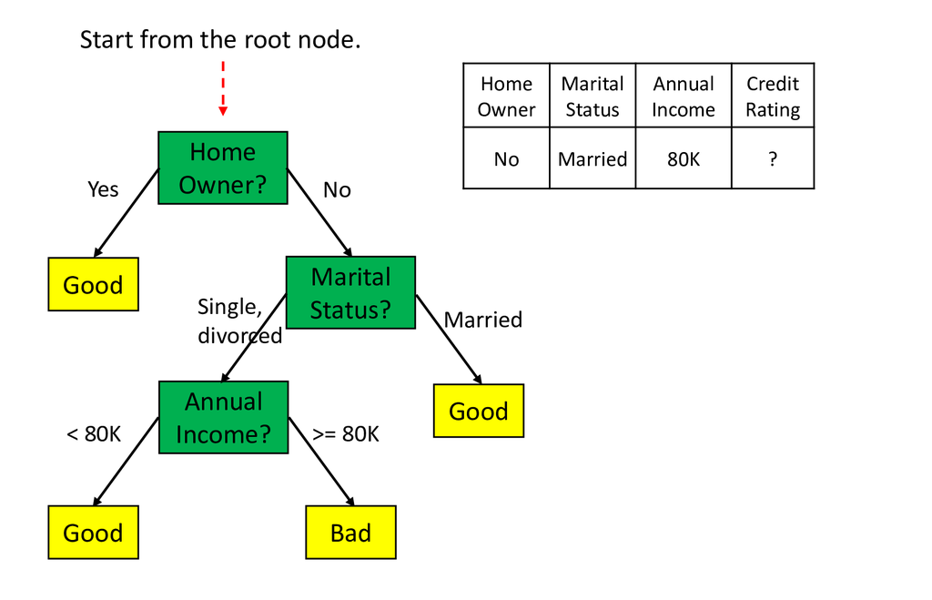

Estructura de un árbol de decisión

Fuente: [Medium](https://medium.com/towards-data-engineering/100-days-of-machine-learning-on-databricks-day-63-decision-trees-5d4df25b194f)

## ¿Cómo se construye un árbol?

1. Empezar con todos los datos en la raíz
2. Buscar la variable y el punto de corte que mejor separen las clases
   - Se usa un criterio como Gini o entropía (miden la “impureza” del nodo)
3. Dividir los datos en dos grupos según esa regla
4. Repetir recursivamente para cada grupo
5. Parar cuando se cumple un criterio:
   - Profundidad máxima
   - Mínimo de observaciones en un nodo
   - Sin mejora significativa
- El algoritmo es codicioso (greedy): en cada paso busca la mejor división local, sin mirar el panorama global

**Ejemplo paso a paso**

```
Datos: 500 personas, 265 votaron

Paso 1: ¿edad > 35?
  ├── Sí (300 personas, 200 votaron)
  │   Paso 2: ¿educación > 12?
  │   ├── Sí → Predecir: VOTÓ ✅
  │   └── No → Predecir: NO VOTÓ ❌
  └── No (200 personas, 65 votaron)
      Paso 2: ¿interés_política > 3?
      ├── Sí → Predecir: VOTÓ ✅
      └── No → Predecir: NO VOTÓ ❌

Cada pregunta busca la "mejor"
separación posible
```

## Ventajas y problemas de los árboles

**Ventajas**

- Muy interpretables: se pueden visualizar y explicar
- Capturan interacciones entre variables automáticamente
- No requieren escalado de variables (funcionan con valores originales)
- Manejan variables numéricas y categóricas sin transformación
- Pueden capturar relaciones no lineales

**Problemas**

- Sobreajuste severo: los árboles profundos memorizan los datos
- Alta varianza: un pequeño cambio en los datos puede producir un árbol completamente diferente
- Inestabilidad: muy sensibles a la muestra de entrenamiento
- Solución: en lugar de un solo árbol, usar muchos árboles
- Eso nos lleva a los Random Forests

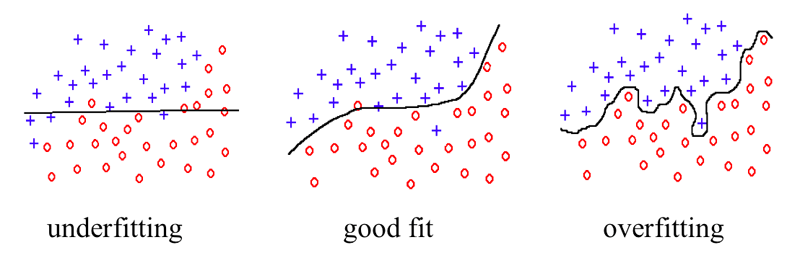

## Árboles de decisión en R

Con tidymodels, solo necesitamos cambiar la especificación del modelo:

```r
R> # Ajustar un árbol de decisión (spec + fit en una sola pipeline)
R> ajuste_arbol <- decision_tree(tree_depth = 5, min_n = 10) |>
+   set_engine("rpart") |>
+   set_mode("classification") |>
+   fit(apoya_democracia ~ ., data = datos_train)
R>
R> # Evaluar: accuracy y ROC-AUC en test
R> pred_arbol <- augment(ajuste_arbol, datos_test)
R> pred_arbol |> accuracy(truth = apoya_democracia, estimate = .pred_class)
```

```
# A tibble: 1 × 3
  .metric  .estimator .estimate
  <chr>    <chr>          <dbl>
1 accuracy binary         0.709
```

```r
R> pred_arbol |> roc_auc(truth = apoya_democracia, .pred_si, event_level = "second")
```

```
# A tibble: 1 × 3
  .metric .estimator .estimate
  <chr>   <chr>          <dbl>
1 roc_auc binary         0.613
```

- Noten que la interfaz es idéntica: solo cambiamos `logistic_reg()` por `decision_tree()`, ¡la misma sintaxis para todos los modelos!
- `tree_depth` y `min_n` son hiperparámetros: controlan la complejidad del modelo
- `augment()` agrega las predicciones al test set; una sola llamada da todo lo necesario para cualquier métrica de yardstick

## Visualizar un árbol de decisión

- Una de las grandes ventajas de los árboles es que se pueden visualizar
- Con el paquete `rpart.plot`:

```r
R> library(rpart.plot)
R>
R> # Extraer el modelo rpart del ajuste tidymodels
R> arbol_rpart <- extract_fit_engine(ajuste_arbol)
R>
R> # type=4: muestra reglas en todos los nodos
R> # extra=104: clase predicha + % de observaciones
R> # roundint=FALSE: evita warning con predictores
R> # no enteros
R> rpart.plot(arbol_rpart,
+            type     = 4,
+            extra    = 104,
+            roundint = FALSE)
```

**Árbol ajustado a nuestros datos:**

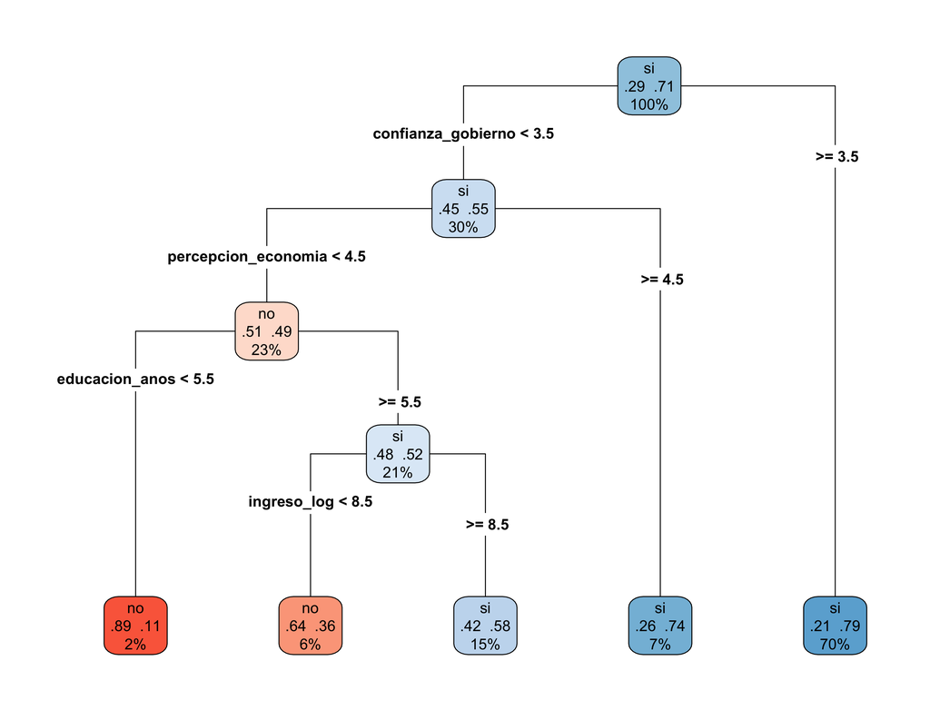

¡Cualquier persona puede entender este modelo, incluso sin formación técnica!

## Poda (pruning): controlando la complejidad

- Un árbol sin restricciones crece hasta memorizar los datos
- La poda (pruning) reduce su complejidad: pre-poda (frenar el crecimiento antes) o post-poda (recortar ramas que no mejoran)
- En tidymodels se controla con hiperparámetros: `tree_depth` (profundidad máxima), `min_n` (mínimo por nodo) y `cost_complexity` (penalización por complejidad)

**El trade-off (con nuestros datos):**

**Código**

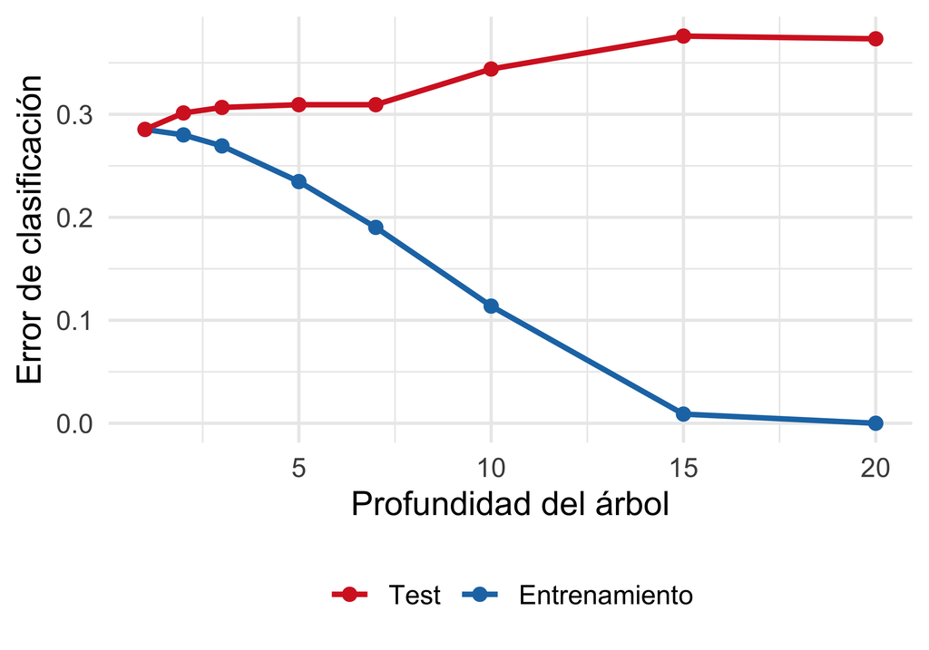

```r
R> profs <- c(1, 2, 3, 5, 7, 10, 15, 20)
R> err <- purrr::map_dfr(profs, function(d) {
+   fit <- rpart(apoya_democracia ~ .,
+                data    = datos_train,
+                control = rpart.control(maxdepth  = d,
+                                        minsplit  = 2,
+                                        minbucket = 1,
+                                        cp        = 0))
+   tibble::tibble(
+     profundidad = d,
+     train = mean(predict(fit, datos_train, type = "class") !=
+                  datos_train$apoya_democracia),
+     test  = mean(predict(fit, datos_test,  type = "class") !=
+                  datos_test$apoya_democracia)
+   )
+ })
R>
R> err |>
+   tidyr::pivot_longer(c(train, test),
+                       names_to = "conjunto", values_to = "error") |>
+   ggplot(aes(profundidad, error, colour = conjunto)) +
+   geom_line(linewidth = 1) +
+   geom_point(size = 2) +
+   scale_colour_manual(values = c(train = "#1f77b4", test = "#d62728"),
+                       labels = c(train = "Entrenamiento", test = "Test")) +
+   labs(x = "Profundidad del árbol", y = "Error de clasificación",
+        colour = NULL) +
+   theme_minimal(base_size = 13) +
+   theme(legend.position = "bottom")
```

A partir de cierta profundidad, el error en test empeora mientras el error en train sigue bajando: la poda previene el sobreajuste

# Random Forests

## La idea detrás de Random Forest

- Un solo árbol es inestable y propenso al sobreajuste
- Solución: combinar muchos árboles y promediar sus predicciones
- Random Forest ([Breiman, 2001](https://doi.org/10.1023/A:1010933404324)) = un conjunto de árboles de decisión
- Dos fuentes de aleatoriedad:
  1. Bootstrap: cada árbol entrena con una muestra diferente de los datos (con reemplazo)
  2. Subconjunto de variables: en cada división, cada árbol solo considera un subconjunto aleatorio de variables
- El resultado: árboles diversos cuyos errores se cancelan al promediar, y la predicción mejora
- Así, RF reduce la varianza sin aumentar mucho el sesgo, y suele funcionar bien sin mucha afinación de hiperparámetros

```
Random Forest con 500 árboles:

Árbol 1: muestra 1, variables {A,C,F}
  → Predicción: VOTÓ

Árbol 2: muestra 2, variables {B,D,E}
  → Predicción: NO VOTÓ

Árbol 3: muestra 3, variables {A,D,G}
  → Predicción: VOTÓ

...

Árbol 500: muestra 500, variables {C,E,F}
  → Predicción: VOTÓ

Predicción final: VOTÓ
(mayoría de votos entre los 500 árboles)
```

La sabiduría de la multitud: ¡muchos modelos “mediocres” juntos hacen un modelo excelente!

## Random Forest en R

De nuevo, con tidymodels solo cambiamos la especificación:

```r
R> # Ajustar Random Forest (importance = "permutation" lo usamos después en VIP)
R> ajuste_rf <- rand_forest(trees = 2000, mtry = 2, min_n = 5) |>
+   set_engine("ranger", seed = 1, importance = "permutation") |>
+   set_mode("classification") |>
+   fit(apoya_democracia ~ ., data = datos_train)
R>
R> # Evaluar: accuracy y ROC-AUC en test
R> pred_rf <- augment(ajuste_rf, datos_test)
R> pred_rf |> accuracy(truth = apoya_democracia, estimate = .pred_class)
```

```
# A tibble: 1 × 3
  .metric  .estimator .estimate
  <chr>    <chr>          <dbl>
1 accuracy binary         0.715
```

```r
R> pred_rf |> roc_auc(truth = apoya_democracia, .pred_si, event_level = "second")
```

```
# A tibble: 1 × 3
  .metric .estimator .estimate
  <chr>   <chr>          <dbl>
1 roc_auc binary         0.676
```

- `ranger` es una implementación rápida y eficiente de Random Forest en R

**Hiperparámetros principales**

| Parámetro | Descripción |
| --- | --- |
| `trees` | Número de árboles (más = mejor, pero más lento) |
| `mtry` | Variables a considerar en cada división |
| `min_n` | Mínimo de observaciones por nodo |

- `mtry` $= \sqrt{p}$ (clasificación) o $p/3$ (regresión); restringir las variables por división fuerza a los árboles a ser diferentes. En la práctica, los valores por defecto funcionan bien

## Importancia de variables

- Los Random Forests no son tan interpretables como un solo árbol o una regresión logística
- Pero podemos medir la importancia de cada variable
- ¿Cómo? Medir cuánto empeora la predicción si permutamos (mezclamos) los valores de una variable
  - Si mezclar `edad` hace que el modelo sea mucho peor, entonces `edad` es importante
  - Si mezclar `zona` no cambia nada, entonces `zona` no aporta mucho
- Esto nos da un ranking de variables por su contribución al modelo
- Útil para entender qué factores importan, aunque no nos diga la dirección del efecto

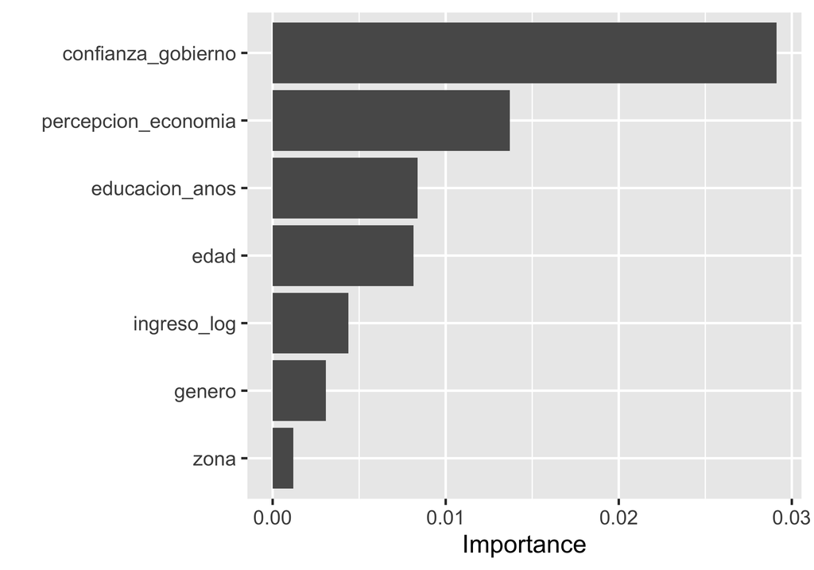

```r
R> vip(ajuste_rf, num_features = 7)
```

- Usamos importancia por permutación (robusta); existen otras como Gini (rápida pero sesgada hacia variables con muchas categorías) y SHAP (más detallada, más avanzada). Para profundizar: [Molnar, *Interpretable ML*](https://christophm.github.io/interpretable-ml-book/)

## Gráficos de dependencia parcial (PDP)

- La importancia nos dice qué variables importan
- Los Partial Dependence Plots (PDP) nos dicen cómo afectan
- Muestran el efecto marginal de una variable sobre la predicción
- Útiles para entender relaciones no lineales

```r
R> library(pdp)
R>
R> ajuste_rf |>
+   partial(pred.var    = "confianza_gobierno",
+           which.class = "si",
+           prob        = TRUE,
+           train       = datos_train) |>
+   autoplot()
```

**PDP: confianza en el gobierno → P(apoya democracia)**

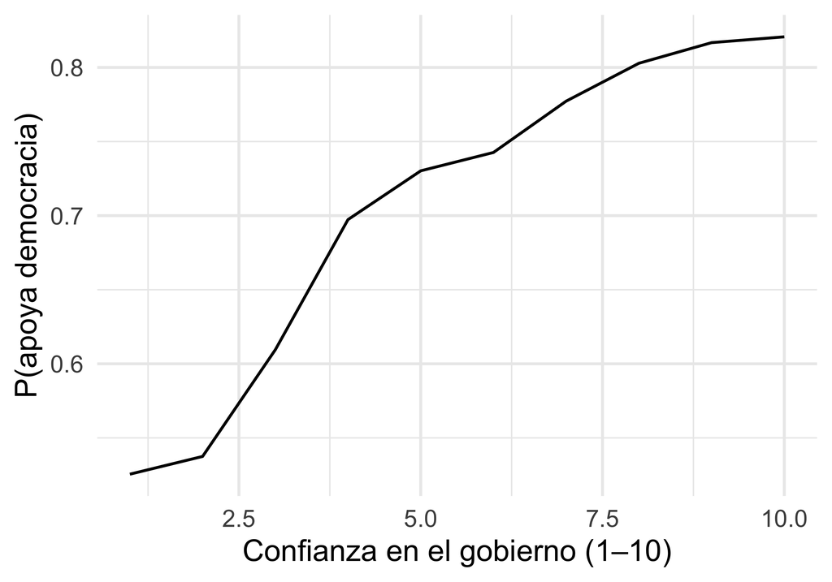

# Ajuste de hiperparámetros (tuning)

## Ajuste de hiperparámetros (tuning)

- Los hiperparámetros (ej. `mtry`, `min_n`) se fijan antes de entrenar; los valores por defecto suelen servir, pero no siempre son óptimos
- El tuning prueba muchas combinaciones y elige la mejor por validación cruzada (nunca con los datos de test)
- El patrón en tidymodels:
  1. marcar parámetros con `tune()`
  2. definir una grilla de valores
  3. evaluar cada combinación con `tune_grid()` sobre los folds (`resamples = folds`, `grid = grilla`)
  4. `select_best()` + `finalize_model()` para el ajuste final

```r
R> # 1. Hiperparámetros a ajustar con tune()
R> modelo_rf_tune <- rand_forest(mtry = tune(), min_n = tune()) |>
+   set_engine("ranger", seed = 1) |>
+   set_mode("classification")
R>
R> # 2. Grilla de valores + folds de validación cruzada
R> grilla <- grid_regular(mtry(range = c(2, 10)),
+                        min_n(range = c(5, 20)), levels = 4)
R> folds  <- vfold_cv(datos_train, v = 5,
+                    strata = apoya_democracia)
R>
R> # 3. Probar cada combinación con CV
R> resultados <- tune_grid(modelo_rf_tune,
+   apoya_democracia ~ ., resamples = folds,
+   grid = grilla, metrics = metric_set(roc_auc))
R>
R> # 4. Elegir la mejor y entrenar el modelo final
R> mejor <- select_best(resultados, metric = "roc_auc")
R> ajuste_final <- finalize_model(modelo_rf_tune, mejor) |>
+   fit(apoya_democracia ~ ., data = datos_train)
```

El tuning mejora el rendimiento pero toma tiempo. Lo ejecutan paso a paso en el laboratorio

# Gradient Boosting

## Más allá de Random Forest: Gradient Boosting

- Random Forest entrena muchos árboles en paralelo y promedia
- Gradient Boosting los entrena en secuencia: cada árbol nuevo intenta corregir los errores del anterior
- Suele dar muy buen rendimiento, pero tiene muchos hiperparámetros (número de árboles, profundidad, tasa de aprendizaje), así que el tuning que acabamos de ver se vuelve esencial
- Implementaciones populares:
  - XGBoost: muy usado en competencias de Kaggle
  - LightGBM: rápido para datasets grandes
  - CatBoost: bueno con variables categóricas

**Random Forest vs. Gradient Boosting:**

|  | RF | Boosting |
| --- | --- | --- |
| Entrenamiento | Paralelo | Secuencial |
| Hiperparámetros | Pocos | Muchos |
| Riesgo de sobreajuste | Bajo | Más alto |
| Velocidad | Rápido | Variable |
| Rendimiento típico | Muy bueno | Excelente |

En tidymodels, la misma interfaz de siempre:

```r
R> modelo_xgb <- boost_tree(
+   trees      = 500,
+   tree_depth = 3,
+   learn_rate = 0.05,
+   min_n      = 10
+ ) |>
+   set_engine("xgboost") |>
+   set_mode("classification")
```

# Comparación de modelos

## Comparando los cuatro modelos

Como los cuatro ajustes comparten la misma estructura, podemos compararlos en una métrica común (ROC-AUC en test):

```r
R> # Los cuatro ajustes de esta sesión (misma estructura, distinta spec)
R> ajuste_log <- logistic_reg() |> set_engine("glm") |> set_mode("classification") |>
+   fit(apoya_democracia ~ ., data = datos_train)
R> ajuste_arbol <- decision_tree(tree_depth = 5, min_n = 10) |> set_engine("rpart") |> set_mode("classification") |>
+   fit(apoya_democracia ~ ., data = datos_train)
R> ajuste_rf <- rand_forest(trees = 2000, mtry = 2, min_n = 5) |> set_engine("ranger", seed = 1, importance = "permutation") |> set_mode("classification") |>
+   fit(apoya_democracia ~ ., data = datos_train)
R> ajuste_xgb <- boost_tree(trees = 500, tree_depth = 3, learn_rate = 0.05, min_n = 10) |> set_engine("xgboost", seed = 1) |> set_mode("classification") |>
+   fit(apoya_democracia ~ ., data = datos_train)
R>
R> # Métrica: ROC-AUC en test
R> tibble(
+   Modelo = c("Logística", "Árbol", "Random Forest", "XGBoost"),
+   `ROC-AUC` = c(
+     augment(ajuste_log,   datos_test) |> roc_auc(apoya_democracia, .pred_si, event_level = "second") |> pull(.estimate),
+     augment(ajuste_arbol, datos_test) |> roc_auc(apoya_democracia, .pred_si, event_level = "second") |> pull(.estimate),
+     augment(ajuste_rf,    datos_test) |> roc_auc(apoya_democracia, .pred_si, event_level = "second") |> pull(.estimate),
+     augment(ajuste_xgb,   datos_test) |> roc_auc(apoya_democracia, .pred_si, event_level = "second") |> pull(.estimate)
+   )
+ ) |> knitr::kable(digits = 3)
```

| Modelo | ROC-AUC |
| --- | --- |
| Logística | 0.707 |
| Árbol | 0.613 |
| Random Forest | 0.676 |
| XGBoost | 0.687 |

- Acá gana la regresión logística, y ni el Random Forest ni el XGBoost la superan. No es casualidad: estos datos se generaron con relaciones lineales, y ningún modelo complejo puede encontrar una estructura no lineal que no existe
- Más complejo no es sinónimo de mejor. Con datos reales, más ruidosos y no lineales, el orden suele invertirse. Por eso siempre hay que comparar antes de elegir

## ¿Qué modelo elegir?

| Criterio | Reg. logística | Árbol | Random Forest | XGBoost |
| --- | --- | --- | --- | --- |
| Interpretabilidad | Alta | Alta (visual) | Baja | Baja |
| Capacidad predictiva | Moderada | Moderada-baja | Alta | Alta |
| Riesgo de sobreajuste | Bajo | Alto | Bajo | Medio-alto |
| Velocidad | Muy rápida | Rápida | Moderada | Moderada |
| Relaciones no lineales | No | Sí | Sí | Sí |
| Hiperparámetros | Ninguno | Pocos | Pocos | Muchos |

- Si necesitan entender por qué el modelo predice algo: regresión logística
- Si necesitan explicar la lógica a no técnicos: árbol de decisión
- Si necesitan la mejor predicción posible: Random Forest o Gradient Boosting, pero solo si los datos tienen estructura no lineal que aprovechar
- En ciencias sociales, la elección depende de si el objetivo es explicar o predecir

## Resumen de la sesión

**Lo que vimos hoy:**

- Cuatro modelos, del más interpretable al más predictivo: regresión logística, árboles de decisión, Random Forests y Gradient Boosting
- Importancia de variables y dependencia parcial para interpretar modelos de caja negra
- Tuning de hiperparámetros con validación cruzada y comparación de modelos en tidymodels
- El modelo más complejo no siempre gana: cuando la relación es lineal, la regresión logística es difícil de superar

**Para explorar:**

- LightGBM y CatBoost, otras variantes de boosting, y SHAP para interpretar modelos de caja negra

La elección del modelo depende del objetivo: ¿explicar o predecir?

## Próximos pasos

- Próxima sesión (2.2): Regresión y regularización
  - Predicción vs. explicación
  - LASSO, Ridge, Elastic Net
  - Selección automática de variables
- Laboratorios (2.3 y 2.4):
  - Clasificación con datos de Latinobarómetro
  - Regresión con datos socioeconómicos
  - Tuning, comparación e interpretación

¡Nos vemos después del descanso!

# Apéndices

## Apéndice 1: La matemática detrás de los árboles

- El árbol busca la división que minimice la impureza de los nodos resultantes
- La medida más común es el índice de Gini:

$$\text{Gini}(t) = 1 - \sum_{k=1}^{K} p_k^2$$

donde $p_k$ es la proporción de la clase $k$ en el nodo $t$

- Nodo puro (una sola clase): $\text{Gini} = 0$
- Nodo 50/50 (máxima mezcla): $\text{Gini} = 0.5$
- El algoritmo evalúa cada variable y cada punto de corte posible, y elige la división con menor Gini ponderado:

$$\text{Gini}_{\text{split}} = \frac{n_L}{n} \text{Gini}(t_L) + \frac{n_R}{n} \text{Gini}(t_R)$$

**Ejemplo con nuestros datos (apoyo a la democracia)**

| Nodo | Sí | No | Gini |
| --- | --- | --- | --- |
| Raíz | 804 | 321 | 0.408 |
| confianza_gobierno < 3.5 | 186 | 152 | 0.495 |
| confianza_gobierno ≥ 3.5 | 618 | 169 | 0.337 |

$\text{Gini}_{\text{split}} = \tfrac{338}{1125}(0.495) + \tfrac{787}{1125}(0.337) = 0.385$

Como $0.385 < 0.408$, esta división mejora la separación de las clases.

## Apéndice 2: Aplicaciones en ciencias sociales

**[Muchlinski et al. (2016)](https://doi.org/10.1093/pan/mpv024): Predicción de guerras civiles**

- Compararon regresión logística con Random Forest
- RF tuvo mejor rendimiento predictivo
- [Wang (2019)](https://doi.org/10.1093/pan/mpz004) replicó y encontró errores, pero la lección se mantiene
- RF captura interacciones complejas que la regresión no capta

**[Jean et al. (2016)](https://doi.org/10.1126/science.aaf7894): Pobreza desde el espacio**

- Predijeron pobreza en África usando imágenes satelitales
- Random Forest + redes neuronales
- Aplicable a contextos donde los censos son poco frecuentes o poco confiables

**Otros ejemplos en ciencias sociales:**

- Predicción de deserción escolar: identificar estudiantes en riesgo antes de que abandonen
- Scoring crediticio alternativo: las fintech como Nubank usan ML para evaluar clientes sin historial bancario
- Detección de fraude electoral: análisis de patrones anómalos en resultados
- Predicción de violencia: modelos para anticipar zonas de riesgo
- Análisis de opinión pública: clasificación de textos sobre políticas públicas

En todos estos casos, RF es un punto de partida común

# Nos vemos en la próxima sesión 🤓